# Week2 多重比较 和 Two-way ANOVA

# 习题1 多重比较

使用第一周的Project1.csv数据

## 背景描述

为了调查吃巧克力对心血管健康的影响，实验由三种类型的巧克力组成：100g的黑巧克力，含有200mg全脂牛奶的100g黑巧克力和200g的牛奶巧克力。12个实验对象：7女5男。在不同的天数里，每个实验对象将吃一种类型的巧克力，一个小时后测量他们血浆的总抗氧能力。 这是一个因子水平数 𝑎 = 3 和重复次数 m = 12 的单因子实验。

## 数据描述

实验次序本身具有随机性，无需再随机化

```python
import pandas as pd
print('Randomized test sequence: \n', pd.read_csv('Project1.csv'))
```

```
Randomized test sequence:
     Obs  Chocolate  Capacity
0     1          1     118.8
1     2          1     122.6
2     3          1     115.6
3     4          1     113.6
4     5          1     119.5
5     6          1     115.9
6     7          1     115.8
7     8          1     115.1
8     9          1     116.9
9    10          1     115.4
10   11          1     115.6
11   12          1     107.9
12    1          2     105.4
```

[output cut: 23 more lines]

## 问题

注：这里使用 $\alpha=0.05$ 的显著性水平

1. 用Tukey方法，通过直接调用 statmodels 库中的 pairwise_tukeyhsd() 函数比较p值，比较 3 种巧克力对心血管健康的影响两两是否存在差异.

```python
# Import standard packages
import numpy as np
import pandas as pd
import scipy.stats as stats # 统计函数
import matplotlib.pyplot as plt
import math

# Import additional packages
from statsmodels.formula.api import ols
from statsmodels.stats.anova import anova_lm

alpha = 0.05
a = 3
m = 12
df = pd.read_csv('Project1.csv')
df = df[['Chocolate', 'Capacity']]
# print(df.columns)
df.columns = ['Type','Capacity']
print(df)
```

```
    Type  Capacity
0      1     118.8
1      1     122.6
2      1     115.6
3      1     113.6
4      1     119.5
5      1     115.9
6      1     115.8
7      1     115.1
8      1     116.9
9      1     115.4
10     1     115.6
11     1     107.9
12     2     105.4
13     2     101.1
```

[output cut: 22 more lines]

### Q1: 试用Tukey比较 3 种巧克力对心血管健康的影响两两是否存在差异.

首先先使用onw-way ANOVA模型（详见第一周实验内容），判断3种巧克力对心血管健康的影响是否存在差异. 原假设： 𝐻0:𝜇1=𝜇2=𝜇3;

备择假设： 𝐻1:𝜇1,𝜇2,𝜇3不全相等

```python
data = df.values # .values will turn pandas into Numpy
list_type = [1, 2, 3]
groups = [data[data[:,0] == atype,1] for atype in list_type]

stats.f_oneway(groups[0], groups[1], groups[2])
```

```
F_onewayResult(statistic=93.57559776071176, pvalue=2.5152590041683006e-14)
```

由于p值小于0.05，，故拒绝原假设，即3种巧克力对心血管健康的影响存在差异。

接下来，使用 statmodels 库中的 pairwise_tukeyhsd() 函数进行Tukey检验

原假设： 𝐻𝑖𝑗0:𝜇𝑖=𝜇𝑗,1≤𝑖<𝑗≤3

```
 Multiple Comparison of Means - Tukey HSD, FWER=0.05
=====================================================
group1 group2 meandiff p-adj  lower    upper   reject
-----------------------------------------------------
     1      2 -15.3583 0.001 -18.5935 -12.1231   True
     1      3  -15.875 0.001 -19.1102 -12.6398   True
     2      3  -0.5167   0.9  -3.7519   2.7185  False
-----------------------------------------------------
```

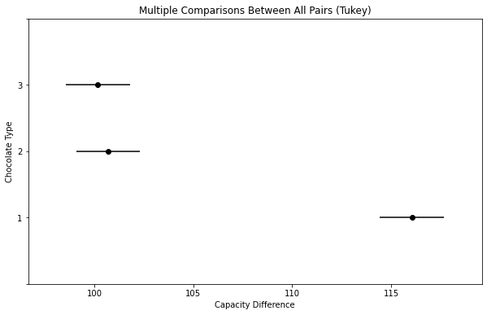

```python
from statsmodels.stats.multicomp import pairwise_tukeyhsd

# perform Tukey's test
tukey = pairwise_tukeyhsd(endog=df['Capacity'], groups=df['Type'], alpha=alpha)

#display results
print(tukey)

tukey.plot_simultaneous(ylabel= 'Chocolate Type', xlabel= 'Capacity Difference')
print('\n')
```

可以得到1\2和1\3两种巧克力对心血管健康的影响均值之间差异的p值为0.001，小于显著性水平0.055.拒绝原假设，认为1\2和1\3均值存在显著差异。 2\3均值之间差异的p值为0.9，大于显著性水平0.05，故接受原假设，不能认为两者均值存在显著差异。

# 习题2 Two-way ANOVA

使用Project2.csv数据

## 数据描述

| 变量名 | 变量含义 | 变量类型 | 变量取值范围 |
| --- | --- | --- | --- |
| （自变量）Glass_Type | 玻璃材料类型 | categorical variable | [1，2，3] |
| （自变量）Temperature | 温度 | continuous variable | [100, 125, 150] |
| （因变量）Light_Output | 输出光 | continuous variable | Real |

## 问题

注：这里使用 $\alpha=0.05$ 的显著性水平

1. 试用Two-way ANOVA模型判断玻璃类型和温度对输出光是否有显著影响.
2. 用适合的残差图，判断该实验用Two-way ANOVA模型是否恰当.
3. 选出一种玻璃类型 使得不论温度高低都能使示波器管的输出光较高.
4. 如何对这种示波器管的输出光进行预测？

## 解决方案

```python
# Import standard packages
import numpy as np
import pandas as pd
import scipy.stats as stats
import matplotlib.pyplot as plt
import math

# Import additional packages
from statsmodels.formula.api import ols
from statsmodels.stats.anova import anova_lm

alpha = 0.05
a = 3
b = 3
m = 3

df = pd.read_csv('Project2.csv')
df.columns = ['Glass_Type', 'Temperature', 'Light_Output']
print(df.head())

data = df.values
list_type = [1, 2, 3]
list_temp = [100, 125, 150]

df_grouped = df.groupby(['Glass_Type', 'Temperature'])
groups = [[[] for i in range(3)] for j in range(3)]
for i in range(a):
    for j in range(b):
        groups[i][j] = list(df_grouped.get_group((list_type[i], list_temp[j]))['Light_Output'])

groups
```

```
   Glass_Type  Temperature  Light_Output
0           1          100           580
1           1          100           568
2           1          100           570
3           2          100           550
4           2          100           530
```

```
[[[580, 568, 570], [1090, 1087, 1085], [1392, 1380, 1386]],
 [[550, 530, 579], [1070, 1035, 1000], [1328, 1312, 1299]],
 [[546, 575, 599], [1045, 1053, 1066], [867, 904, 889]]]
```

### Q1: 试用Two-way ANOVA模型判断玻璃类型和温度对输出光是否有显著影响.

试判断玻璃类型和和温度对输出光是否有显著影响，使用 statmodels 库中的 anova_lm() 函数进行Two-Way ANOVA。

需要针对以下三组问题进行检验：

其一，判断玻璃类型和温度是否对输出光有交互作用

原假设: 𝐻03:(𝛼𝛽)𝑖𝑗=0,∀𝑖,𝑗 vs 备择假设： 𝐻13:(𝛼𝛽)𝑖𝑗≠0,∃𝑖,𝑗

（如果不存在交互效应，应该用无交互效应的Two-way ANOVA建模）

其二，判断玻璃类型是否对输出光有直接影响

原假设: 𝐻01:𝛼1=𝛼2=⋯=𝛼𝑎=0 vs 备择假设： 𝐻11:𝛼𝑖≠0,∃𝑖 其三，判断温度是否对输出光有直接影响

原假设: 𝐻02:𝛽1=𝛽2=⋯=𝛽𝑏=0 vs 备择假设： 𝐻12:𝛽𝑗≠0,∃𝑗

```python
# Do the two-way ANOVA
model = ols('Light_Output ~ C(Glass_Type) + C(Temperature) + C(Glass_Type):C(Temperature)', df).fit()
anova_results = round(anova_lm(model), 4)
print('\n双因素方差分析表：\n', anova_results)
```

```
双因素方差分析表：
                                 df        sum_sq      mean_sq          F  \
C(Glass_Type)                  2.0  1.508645e+05   75432.2593   206.3706
C(Temperature)                 2.0  1.970335e+06  985167.2593  2695.2595
C(Glass_Type):C(Temperature)   4.0  2.905517e+05   72637.9259   198.7257
Residual                      18.0  6.579333e+03     365.5185        NaN

                              PR(>F)
C(Glass_Type)                    0.0
C(Temperature)                   0.0
C(Glass_Type):C(Temperature)     0.0
Residual                         NaN
```

### Q2: 用适合的残差图，判断该实验用Two-way ANOVA模型是否恰当.

检验设定模型的恰当性。仍然希望从三个角度进行分析：（1）独立（2）方差齐性 以及（3）正态性。

这次希望提供一个新的视角，通过绘制合适的残差图来说明Two-way ANOVA模型是否恰当

```python
# 计算电池寿命数据的残差

data_res = data.astype(float)
for i in list_material:
    for j in list_temp:
        cnt = data[(data[:,0] == i) & (data[:,1] == j),2]
        data_res[(data_res[:,0] == i) & (data_res[:,1] == j),2] = cnt-np.mean(cnt)
df = pd.DataFrame(data_res, columns = ['Glass_Type', 'Temperature', 'Light_Output_res'])
print(df.head())

res = data_res[:, 2]
```

```
   Glass_Type  Temperature  Light_Output_res
0         1.0        100.0          7.333333
1         1.0        100.0         -4.666667
2         1.0        100.0         -2.666667
3         2.0        100.0         -3.000000
4         2.0        100.0        -23.000000
```

#### 残差分析1：残差与不同因子水平的关系图

等价于方差齐性检验

#### 残差分析1.1：残差与材料的关系图

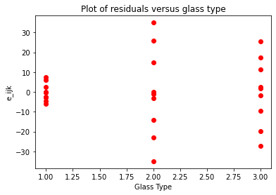

```python
# 残差对玻璃类型的关系图

y3 = data_res[:,0]
plt.scatter(y3, res, c = 'red')
plt.title('Plot of residuals versus glass type')
plt.xlabel('Glass Type')
plt.ylabel('e_ijk')
```

上图显示出方差微弱的不等性：材料类型为第二种时，比其他情况下方差大。

#### 残差分析1.2：残差与温度的关系图

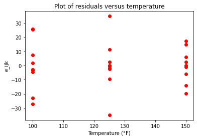

```python
# 残差对温度的关系图
y4 = data_res[:,1]
plt.scatter(y4, res, c = 'red')
plt.title('Plot of residuals versus temperature')
plt.xlabel('Temperature (°F)')
plt.ylabel('e_ijk')
```

上图显示出方差微弱的不等性：温度为 125℉ 时，比其他情况下方差大。

#### 残差分析1.3: 残差与预测值的关系图

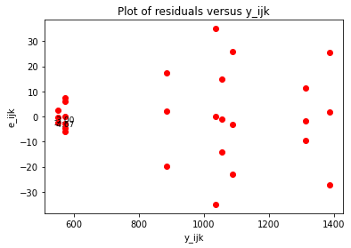

```python
# 残差与预测值的关系图
# 使用每一组的均值作为该组的预测值
y2 = []
for i in list_material:
    for j in list_temp:
        for k in range(m):
            y2.append(np.mean(data[(data[:,0] == i) & (data[:,1] == j), 2]))
plt.scatter(y2, res, c = 'red')
plt.text(y2[0], res[1], '%.2f' % float(res[1]), ha='center', va= 'bottom', fontsize=9)
plt.text(y2[0], res[3], '%.2f' % float(res[3]), ha='center', va= 'bottom', fontsize=9)
plt.title('Plot of residuals versus y_ijk')
plt.xlabel('y_ijk')
plt.ylabel('e_ijk')
```

由上图可以看出，当光输出增加时，残差方差有增长的趋势。基本满足方差齐性。

##### 【复习】利用Bartlett检验 和 Levene检验

```python
# 用Bartlett检验进行方差齐性检验
stats.bartlett(groups[0][0], groups[0][1], groups[0][2], groups[1][0], groups[1][1], groups[1][2], groups[2][0], groups[2][1], groups[2][2])
```

```
BartlettResult(statistic=13.438626419880046, pvalue=0.09762263652008246)
```

Bartlett检验的P值大于 0.05 故接受原假设，即残差具有方差齐性。

```python
# 用Levene检验进行方差齐性检验
stats.levene(groups[0][0], groups[0][1], groups[0][2], groups[1][0], groups[1][1], groups[1][2], groups[2][0], groups[2][1], groups[2][2])
```

```
LeveneResult(statistic=1.254770164787511, pvalue=0.32529552216983837)
```

Levene检验的P值大于 0.05 故接受原假设，即残差具有方差齐性。

#### 残差分析2: 残差的正态概率图

等价于正态性检验

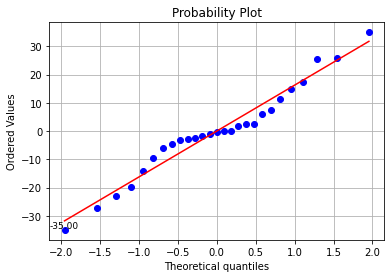

```python
# 残差的正态概率图
res = data_res[:, 2]
osm, osr = stats.probplot(res, dist = 'norm', plot = plt)
x = osm[0][0]
y = osm[1][0]
plt.text(x, y, '%.2f' % float(y), ha='center', va= 'bottom', fontsize=9)
plt.grid()
plt.show()
```

##### 【复习】利用Shapiro-Wilk检验

```python
# 用Shapiro-Wilk检验进行正态性检验
SW, pVal = stats.shapiro(res)
pVal
```

```
0.5236809253692627
```

W检验的P值为 0.52，大于指定的显著性水平 0.05。故认为残差来自服从正态分布的总体。

### Q3：选出一种玻璃类型 使得不论温度高低都能使示波器管的输出光较高.

```
   Glass_Type  Temperature  Light_Output_avg
0         1.0        100.0        572.666667
1         1.0        100.0        572.666667
2         1.0        100.0        572.666667
3         2.0        100.0        553.000000
4         2.0        100.0        553.000000
```

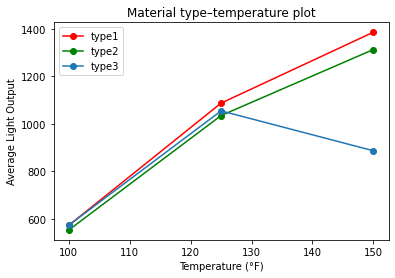

```python
# 固定效应模型分析
data_avg = data.astype(float) * 1
for i in list_material:
    for j in list_temp:
        cnt = data[(data[:,0] == i) & (data[:,1] == j),2]
        data_avg[(data_avg[:,0] == i) & (data_avg[:,1] == j),2] = np.mean(cnt)
df = pd.DataFrame(data_avg, columns = ['Glass_Type', 'Temperature', 'Light_Output_avg'])
print(df.head())

type1 = data_avg[[0,9,18], 2]
type2 = data_avg[[3,12,21], 2]
type3 = data_avg[[6,15,24], 2]
c1 = pd.Series(type1, index = list_temp, name = 'type1')
c2 = pd.Series(type2, index = list_temp, name = 'type2')
c3 = pd.Series(type3, index = list_temp, name = 'type3')
df = pd.concat([c1, c2, c3], axis = 1)

plt.plot(df.iloc[:,0], color = 'red', marker = 'o', label = 'type1')
plt.plot(df.iloc[:,1], color = 'green', marker = 'o', label = 'type2')
plt.plot(df.iloc[:,2], marker = 'o', label = 'type3')
plt.title('Material type–temperature plot')
plt.xlabel('Temperature (°F)')
plt.ylabel('Average Light Output')
plt.legend(['type1', 'type2', 'type3'])
```

上图绘制了每一种处理组合的平均响应图，因为线段不平行，所以交互作用显著。一般来说，不管是什么玻璃类型，在低温处的输出光都较弱。从低温变化至中等温度时，用三种玻璃类型的输出光都有较大幅度的提高。从中等温度变至高温时，使用面板玻璃类型 1 与类型 2 的示波器管输出光增强，且使用玻璃类型 1 的示波器管的输出光要强于使用玻璃类型 2 的示波器管，而使用类型 3 的示波器管输出光变弱。因此如果我们希望选出一种玻璃类型 使得不论温度高低都能使示波器管的输出光较高，选用玻璃类型 1 比较合适。

### Q4: 如何对这种示波器管的输出光进行预测？

一般地，线性回归方法可用于为实验数据拟合相应的模型。

变量的变换规则:

$B$ 表示材料类型因子的主效应。由于材料类型是定性的，有 3 个水平。变量 $B[1]$ 和 $B[2]$ 被认为是示性变量（indicator variable），其定义为:

|  | 1 | 2 | 3 |
| --- | --- | --- | --- |
| $B[1]$ | 1 | 0 | -1 |
| $B[2]$ | 0 | 1 | -1 |

这里我们画出响应曲线（response curve）可以得到响应变量与定量因子——温度的关系。

$$Life = \beta_0+\beta_1A+\beta_2B_1+\beta_3B_2+\beta_4A^2+\beta_5AB_1+\beta_6AB_2+\beta_7A^2B_1+\beta_8A^2B_2$$

```python
# 构造这 8 个变量
# list_A = [100, 125, 150]
list_A = [-1, 0, 1]
list_B1 = [1, 0, -1]
list_B2 = [0, 1, -1]
A = data[:,1] * 1
B1 = B2 = data[:, 0]
for i in range(3):
    A = [list_A[i] if j == list_temp[i] else j for j in A]
    B1 = [list_B1[i] if j == list_type[i] else j for j in B1]
    B2 = [list_B2[i] if j == list_type[i] else j for j in B2]
AA = [A[k] ** 2 for k in range(len(A))]
AB1 = [A[k] * B1[k] for k in range(len(A))]
AB2 = [A[k] * B2[k] for k in range(len(A))]
AAB1 = [AA[k] * B1[k] for k in range(len(A))]
AAB2 = [AA[k] * B2[k] for k in range(len(A))]
df = pd.DataFrame(A, columns = ['A'])
df['B1'] = B1
df['B2'] = B2
df['AA'] = AA
df['AB1'] = AB1
df['AB2'] = AB2
df['AAB1'] = AAB1
df['AAB2'] = AAB2
df['Light_Output'] = data[:,2]
print(df.head())

# 训练模型
model = ols('Light_Output ~ A + B1 + B2 + AA + AB1 + AB2 + AAB1 + AAB2',df).fit()
param = model.params
model.summary()
```

```
   A  B1  B2  AA  AB1  AB2  AAB1  AAB2  Light_Output
0 -1   1   0   1   -1    0     1     0           580
1 -1   1   0   1   -1    0     1     0           568
2 -1   1   0   1   -1    0     1     0           570
3 -1   0   1   1    0   -1     0     1           550
4 -1   0   1   1    0   -1     0     1           530
```

OLS Regression Results

| Dep. Variable: | Light_Output | R-squared: | 0.997 |
| --- | --- | --- | --- |
| Model: | OLS | Adj. R-squared: | 0.996 |
| Method: | Least Squares | F-statistic: | 824.8 |
| Date: | Tue, 28 Sep 2021 | Prob (F-statistic): | 1.78e-21 |
| Time: | 23:43:07 | Log-Likelihood: | -112.51 |
| No. Observations: | 27 | AIC: | 243.0 |
| Df Residuals: | 18 | BIC: | 254.7 |
| Df Model: | 8 |  |  |
| Covariance Type: | nonrobust |  |  |

|  | coef | std err | t | P>\|t\| | [0.025 | 0.975] |
| --- | --- | --- | --- | --- | --- | --- |
| Intercept | 1059.0000 | 6.373 | 166.174 | 0.000 | 1045.611 | 1072.389 |
| A | 314.4444 | 4.506 | 69.779 | 0.000 | 304.977 | 323.912 |
| B1 | 28.3333 | 9.013 | 3.144 | 0.006 | 9.399 | 47.268 |
| B2 | -24.0000 | 9.013 | -2.663 | 0.016 | -42.935 | -5.065 |
| AA | -178.2222 | 7.805 | -22.834 | 0.000 | -194.620 | -161.824 |
| AB1 | 92.2222 | 6.373 | 14.471 | 0.000 | 78.833 | 105.611 |
| AB2 | 65.5556 | 6.373 | 10.287 | 0.000 | 52.167 | 78.944 |
| AAB1 | 70.2222 | 11.038 | 6.362 | 0.000 | 47.032 | 93.412 |
| AAB2 | 76.2222 | 11.038 | 6.905 | 0.000 | 53.032 | 99.412 |

| Omnibus: | 0.570 | Durbin-Watson: | 2.273 |
| --- | --- | --- | --- |
| Prob(Omnibus): | 0.752 | Jarque-Bera (JB): | 0.035 |
| Skew: | 0.009 | Prob(JB): | 0.983 |
| Kurtosis: | 3.175 | Cond. No. | 5.59 |

Warnings:  
[1] Standard Errors assume that the covariance matrix of the errors is correctly specified.

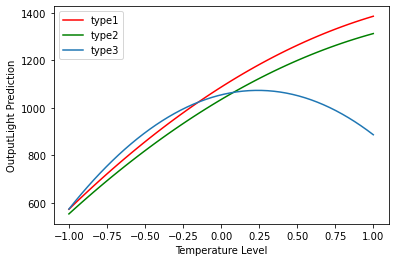

```python
# 拟合响应曲线
temp = np.linspace(-1, 1)
# 材料类型示性变量取分组对应的值
light_type1 = param[0] + param[1] * temp + param[2] * list_B1[0] + param[3] * list_B2[0] + param[4] * (temp ** 2) + param[5] * temp * list_B1[0] + param[6] * temp * list_B2[0] + param[7] * (temp ** 2) * list_B1[0] + param[8] * (temp ** 2) * list_B2[0]
light_type2 = param[0] + param[1] * temp + param[2] * list_B1[1] + param[3] * list_B2[1] + param[4] * (temp ** 2) + param[5] * temp * list_B1[1] + param[6] * temp * list_B2[1] + param[7] * (temp ** 2) * list_B1[1] + param[8] * (temp ** 2) * list_B2[1]
light_type3 = param[0] + param[1] * temp + param[2] * list_B1[2] + param[3] * list_B2[2] + param[4] * (temp ** 2) + param[5] * temp * list_B1[2] + param[6] * temp * list_B2[2] + param[7] * (temp ** 2) * list_B1[2] + param[8] * (temp ** 2) * list_B2[2]

c1 = pd.Series(light_type1, index = temp, name = 'type1')
c2 = pd.Series(light_type2, index = temp, name = 'type2')
c3 = pd.Series(light_type3, index = temp, name = 'type3')
df = pd.concat([c1, c2, c3], axis = 1)

plt.plot(df.iloc[:,0], color = 'red', label = 'type1')
plt.plot(df.iloc[:,1], color = 'green', label = 'type2')
plt.plot(df.iloc[:,2], label = 'type3')
plt.xlabel('Temperature Level')
plt.ylabel('OutputLight Prediction')
plt.legend(['type1', 'type2', 'type3'])
```

玻璃类型为 1： y=1087.33+406.67∗TempLevel−108∗TempLevel2 玻璃类型为 2： y=1035+380∗TempLevel−102∗TempLevel2 玻璃类型为 3： y=1054.67+156.67∗TempLevel−324.67∗TempLevel2 上图显示了这 3 个预测公式声称的响应曲线。